# Life history strategies and host-parasite coevolution

### Learning objectives

- Appreciate the multiple forms parasites can take
- Be able to define general parasite terms (e.g., obligate, facultative, etc.)
- Understand parasite life history tradeoffs
- Be able to quantify parasite specialism

### Parasite diversity

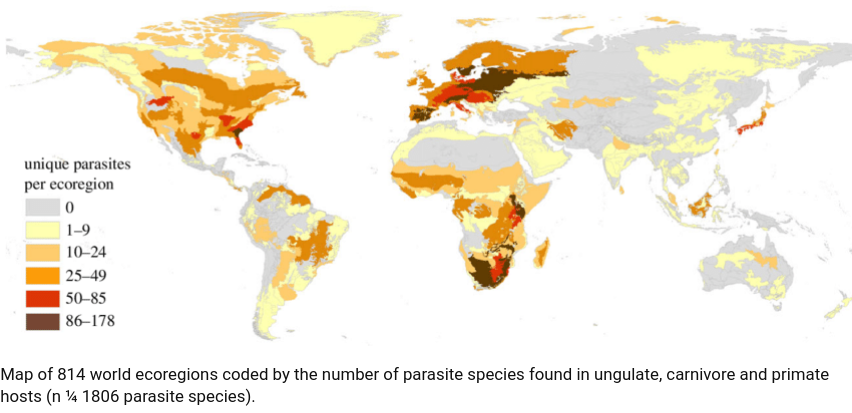

<sub>Byers et al. 2019 *PRSB*</sub>

### Parasite diversity

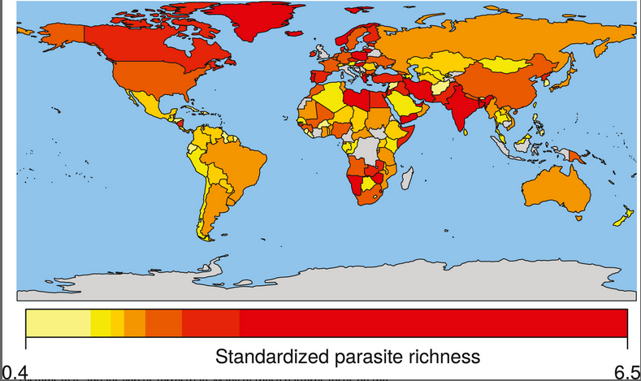

<sub>Dallas et al. 2018 *GEB*</sub>

### How do we really define parasite diversity?

**Diversity in:**

- number (taxonomic)
- phylogenetic
- functional
- infection modes
- tissue infected
- impacts
- host specificity
- …

### Diversity in numbers

### Diversity in phylogenetics

- A host is infected with two parasite species
  - they could be closely related parasites, or quite distantly related parasites
- So when quantifying parasite diversity (either within a region or within a host species), considering the phylogenetic distance between parasites can be used as a measure of diversity

### Phylogenetic diversity for free-living animals

- Take the tree of free-living species
- Calculate some index of dispersion for species found in the local community
- Mean pairwise distance is a common one

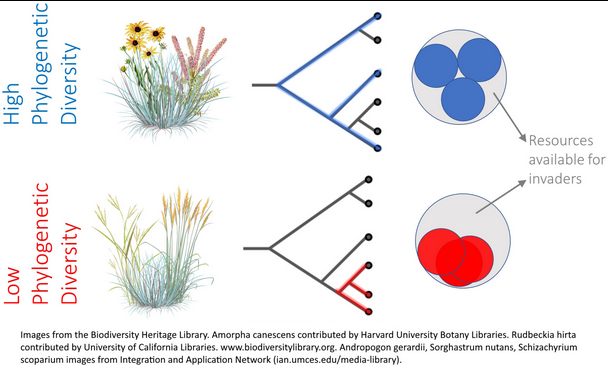

### Quantifying phylogenetic diversity for parasites

- For a given location or host community, what is the ‘index of dispersion’ for the parasite community?
- The parasite phylogeny is used to measure phylogenetic diversity, the host phylogeny is used to calculate phylogenetic specificity

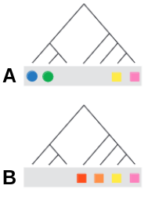

### Phylogenetic diversity of parasites

> What geographic location would be the most phylogenetically diverse for parasites?

### Mammmal richness and phylogenetic diversity

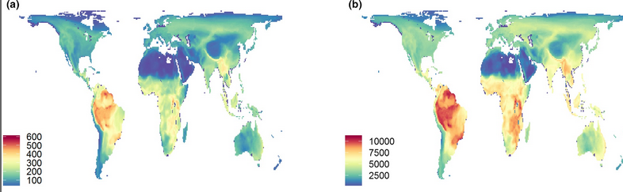

<sub>a is species diversity, b is phylo diversity; Voskamp et al. 2017 *J Biogeography*</sub>

### Host and parasite diversity often related

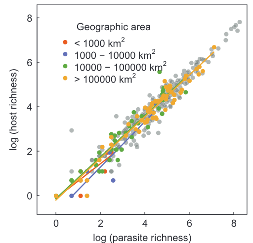

<sub>Dallas et al. 2018 *GEB*</sub>

### Phylogenetic specificity across parasite groups

> What parasites would be most (or least) phylogenetically specific?

### Phylogenetic specificity across parasite groups

- This is broken down by parasite group and transmission mode
- More negative values indicate higher phylo-specificity

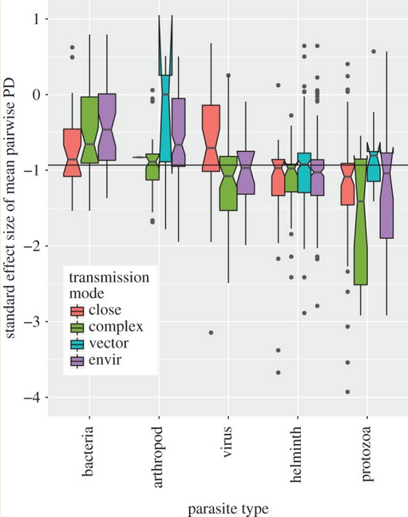

<sub>Park et al. 2018 *PRSB*</sub>

### Phylogenetic specificity versus phylogenetic diversity

- The last slide was phylogenetic specificity (single parasite in host community)
- Phylogenetic diversity could be defined at the parasite community level, so it would use the parasite phylogeny
- So keep in mind the distinction here between diversity and specificity

### Functional diversity

- Scientists have been obsessed with functional diversity for the last 15 years or so
- Argument: quantifying the differences in species traits provides information that the phylogeny may not
- In free-living species, this would be the variance in host body size or plant height or feeding mode

### Functional diversity/specificity

- For parasite species, it is some measure of the variance in the traits of infected host species ( specificity )
- For entire parasite communities, it is the variance in traits of the parasites ( diversity )

> Can you give me an example of both of these?

### Diversity in infection modes

- macroparasites versus microparasites
- direct versus indirect transmission
- simple versus complex life cycle

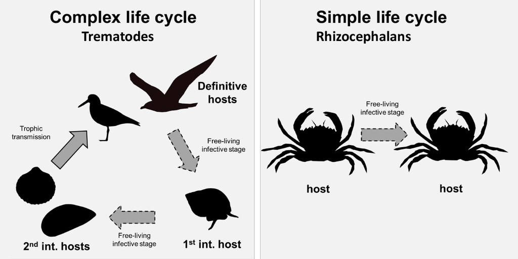

### Env-transmitted pathogen (simple)

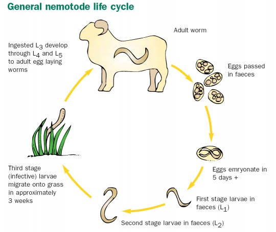

### Complex life cycle

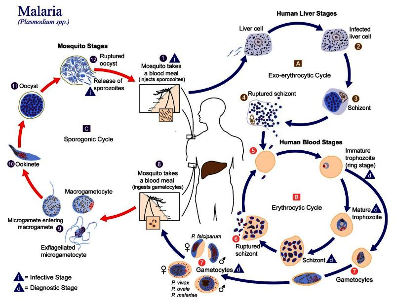

### Diversity in infection modes

- Six parasite strategies:
  - parasitic castration
  - directly transmitted parasitism
  - trophically-transmitted parasitism
  - vector-transmitted parasitism
  - parasitoidism
  - micropredation

### parasitic castrators

- remove the host’s ability to reproduce
- take that energy and/or space
- tradeoff between consumption and longevity faced by parasites

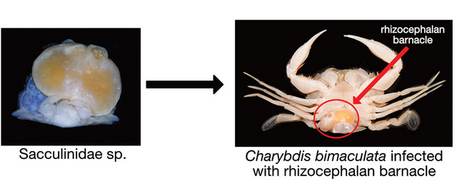

### parasitic castrators

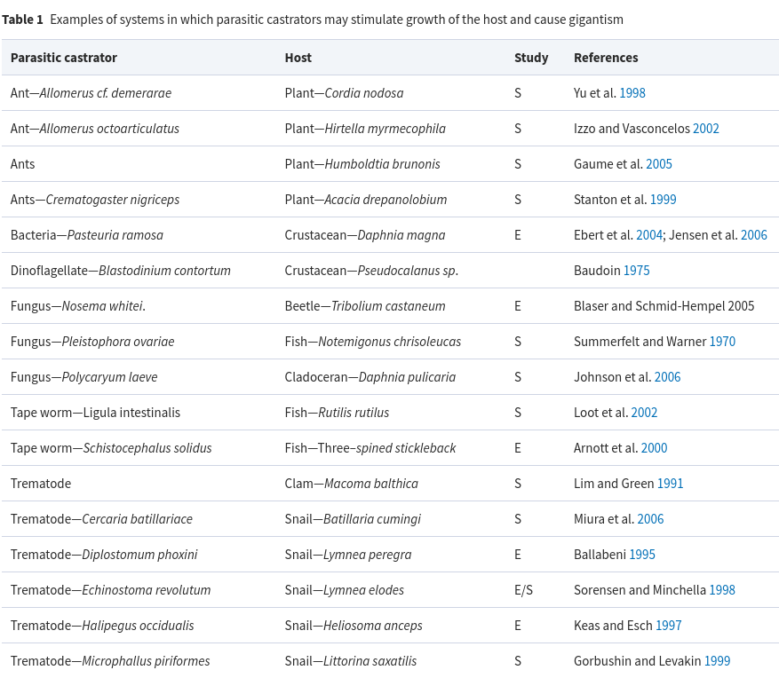

### directly transmitted parasitism

- do not require vector
- this includes environmentally-transmitted pathogens (e.g., cholera)

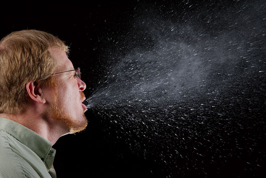

### trophically-transmitted parasitism

- transmitted through predation of the host
- complex life cycle parasites
- can modify host behavior (why?)

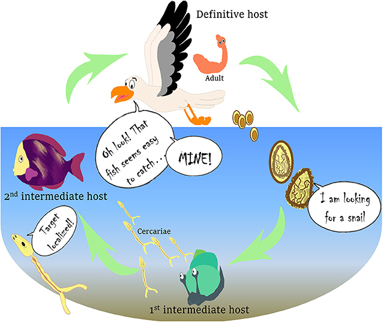

### vector-transmitted parasitism

- Rely on other organisms for transmission (e.g., mosquitos, ticks, lice, fleas, etc.)
- Sometimes reproduce in vector, sometimes only reproduce in definitive host

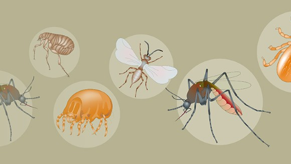

### parasitoidism

- Insects that kill their hosts (so more like predation)
- Larvae live as parasites within infected host

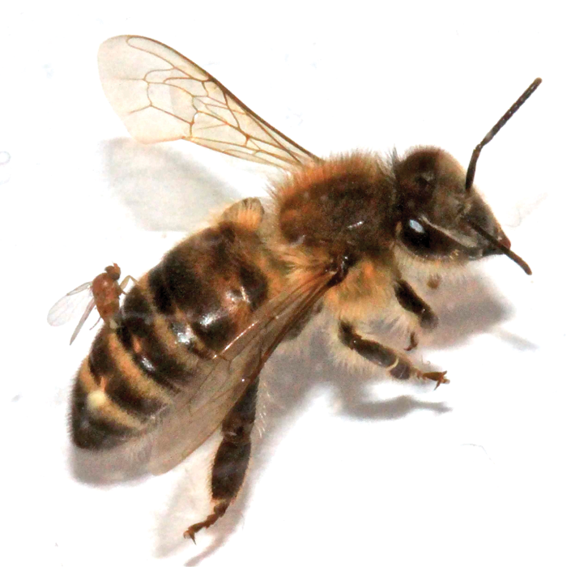

### micropredation

- attacks more than one host (reducing each host individual fitness by small amount)
- e.g., leeches, mosquitos, fleas, ticks, lice

### Diversity in tissue infected

- **Tissue tropism**: range of host tissue types which the pathogen can infect
- e.g., viruses tht must bind to specific cell surface receptors to enter a cell

### How much diversity is there in tissue tropism?

- A fair bit, often related to transmission mode
- Tissue specialist: mumps (parotid salivary glands)
- Tissue generalist: ebola (monocytes, macrophages, dendritic cells, endothelial cells, fibroblasts, hepatocytes, adrenal cortical cells, and epithelial cells)

### Defining tissue tropism is hard

- Could define by system (e.g., circulatory, hepatic, respiratory, etc.)
- By organ (e.g., stomach)
- Or by cell type (e.g., endothelial)
- Or probably some other ways

### Diversity in impacts

- Some parasites have little impact (e.g., some parasitic worms), some have pronounced impact (e.g., anthrax)
- Impacts quantified as
  - morbidity/mortality
  - energetic cost to host
  - fitness cost
  - etc.

### Diversity in host specificity

- **Host specificity**: range and diversity of types of hosts a parasite can infect
- Generalism versus specialism
- We’ve talked about specialism in a couple of ways (taxonomic, phylogenetic, and functional)

> What’s the most generalist parasite you can think of?

## End of lecture 1

### What have we learned

- Parasites are cool
- Parasite diversity can be defined in a bunch of different ways
- Parasites can be specialists or generalits in different ways

> today we will dive into parasite specificity

### Why specialize?

- High infectivity/transmission in preferred host

### Why generalize?

- Need a host to reproduce
- Potential for invasion of new habitats
- Co-extinction is bad

### How do we quantify parasite specialism?

- number of host species infected (host range; taxonomic)
- functional dispersion of host community (functional)
- phylogenetic dispersion of host community (phylogenetic)
- relative utilization of different host species (tropism)?

### Specialism-generalism tradeoffs

- Jack of all trades, master of none?
  - Proposes a relationship between ability to infect and host specificity
  - Generalist parasites should tend to infect with low success (reduced prevalence or intensity)

> But do we see evidence for this relationship?

### Not really (at least for fleas)

- Why does parasite type matter here?

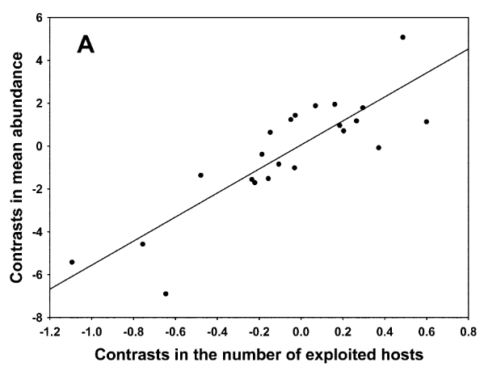

<sub>Krasnov et al. 2004 *Am Nat*</sub>

### We don’t see it for Plasmodium in birds either

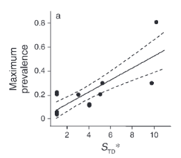

### But there’s a caveat here

- These figures differ a bit
  - First was mean abundance of flea parasite
  - Second was maximum prevalence in most common host
- The distribution of prevalence is important here
  - If I infect one host really well, but 5 other hosts less well, how much of a generalist am I?

> The costs of being a generalist are difficult to clearly define and test

### Let’s look for this relationship in some bigger data

[Global Mammal Parasite Database](https://parasites.nunn-lab.org/)

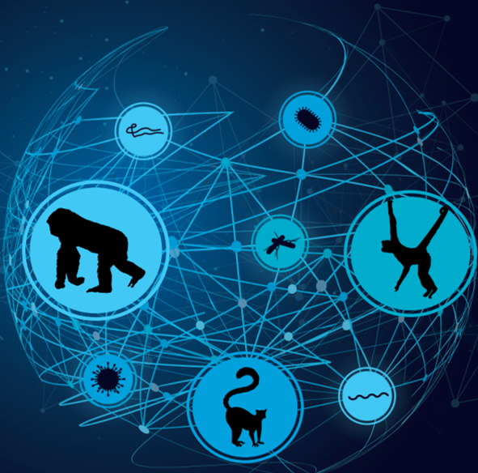

### Let’s look for this relationship in some bigger data

```r
gmpd2 <- gmpd[which(gmpd$Prevalence !=0 & gmpd$Prevalence < 1), ]
gmpd2$Intensity <- as.numeric(gmpd2$Intensity)

gmpd3 <- gmpd2 |>
   group_by(ParasiteCorrectedName) |>
   summarise(hostRange=length(unique(HostCorrectedName)),
      prevalence=mean(Prevalence, na.rm=TRUE),
      intensity=mean(Intensity, na.rm=TRUE),
            maxPrev=max(Prevalence, na.rm=TRUE),
            maxInt=max(Intensity, na.rm=TRUE),
            parType=ParType[1])
```

### Let’s look for this relationship in some bigger data

> (figure from last time I taught this class)

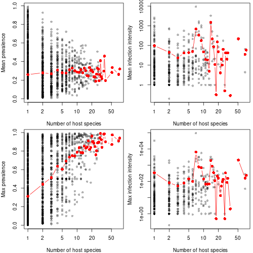

### Concept figure

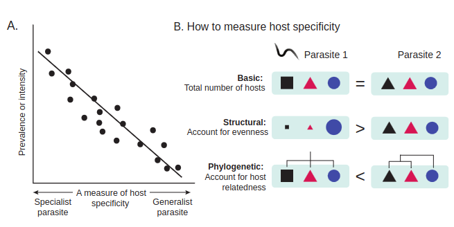

### Figure 2

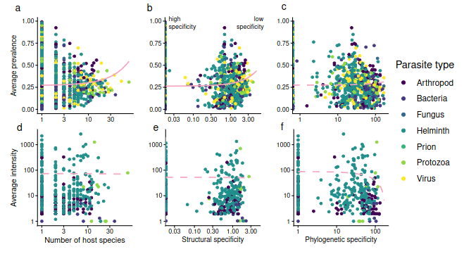

> In review at *Proceedings of the Royal Society B*

### Host-parasite coevolution

- Infection is costly to hosts in terms of fitness, leading to evolution of host defenses
- Parasites *want* to infect, leading to evolution of novel infection strategies

### Host-parasite coevolution

- Possible trajectories of host-parasite coevolution

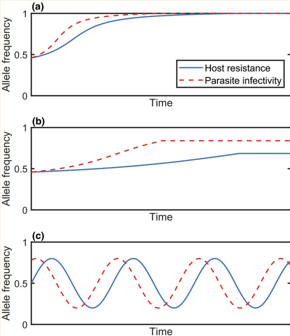

<sub>Buckingham & Ashby 2022 *J Evol Biol*</sub>

### Host-parasite coevolution

- The difference between deterministic and stochastic systems

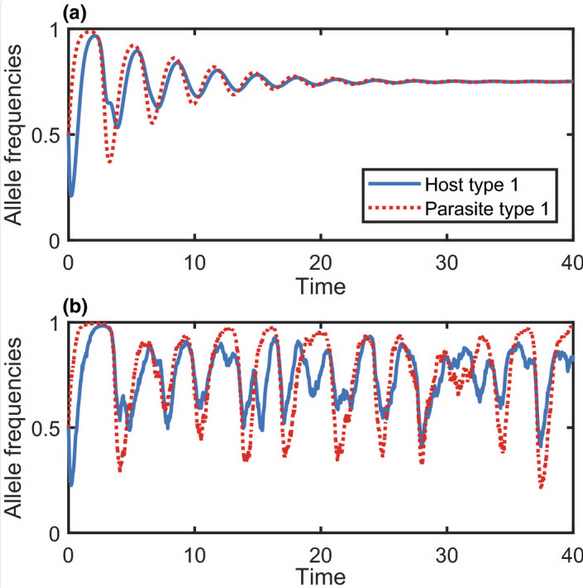

<sub>Buckingham & Ashby 2022 *J Evol Biol*</sub>

### Host-parasite coevolution

- Resistance evolution as a function of the cost on host fitness

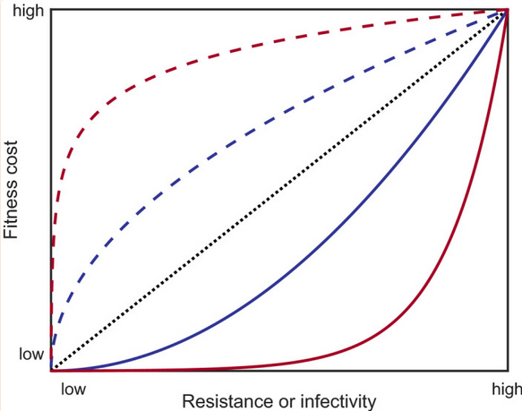

<sub>Buckingham & Ashby 2022 *J Evol Biol*</sub>

### Host-parasite coevolution

- This cyclic pattern of selection/evolution is often referred to as Red Queen dynamics
- Idea comes from *Through the Looking Glass*, where the Alice was running just to keep her place

[figure not shown]

### What happens when resistance is either cheap or hugely beneficial?

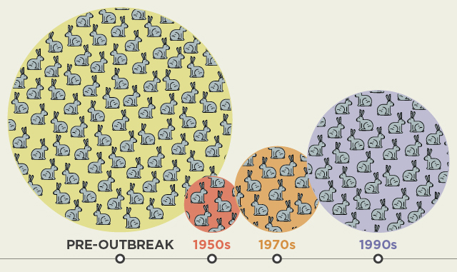

### What happens when resistance is either cheap or hugely beneficial?

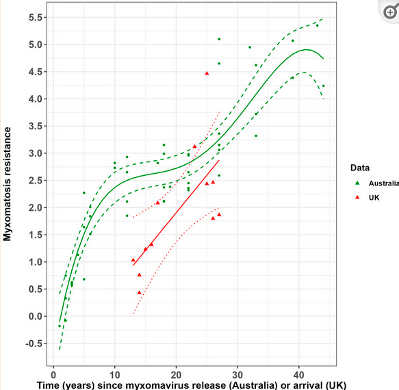

<sub>Cooke et al. 2023 *Epidemiol Infect*</sub>

### Why is this not a great example of Red Queen dynamics?

### What is the “goal” of the parasite?

- To reproduce. So it doesn’t really *want* to kill the host, right?
- But it also has to reproduce and consume some aspect of the host, which comes at a fitness consequence for the host.
- There’s a conflicting balance between
  - trying to reproduce (which causes harm to host)
  - flying under the radar (transmission to the next host)

### optimal virulence

- **Virulence**: pathogen-induced mortality of infected host
- Pathogen needs to grow in infected host, but dead hosts don’t transmit
- So the optimal strategy is not maximal virulence, but some intermediate (or even low) virulence

### What examples do you know of related to changes in virulence in an evolving pathogen?

### Many SARS-COV2 strains through time

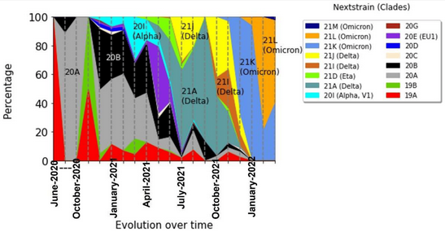

- Initial strain had highest pathogenicity (even though we saw greatest mortality with Alpha)
- Omicron has the lowest pathogenicity

### How have we used virulence evolution to our benefit?

- the creation of live attenuated vaccines
- live vaccines use avirulent strains of the pathogen to induce host immune memory
- e.g., Sabin (oral) polio vaccine; the measles, mumps, rubella, yellow fever, and chicken pox (varicella) vaccines; one of the influenza vaccines (flu mist); the tuberculosis (BCG) vaccine; etc. etc.

### What parasites would not follow this general pattern of virulence attenuation?

- Fungal pathogens, generally
- Pathogens with a long-lived environmental stage (e.g., anthrax)

### optimal virulence

- Essentially a balance between parasite growth and host exploitation
- Idea in this tradeoff model is to maximize lifetime transmission success (LTS)
- This leads to a non-linear relationship between LTS and virulence

> the ideal parasite maximizes LTS

### optimal virulence

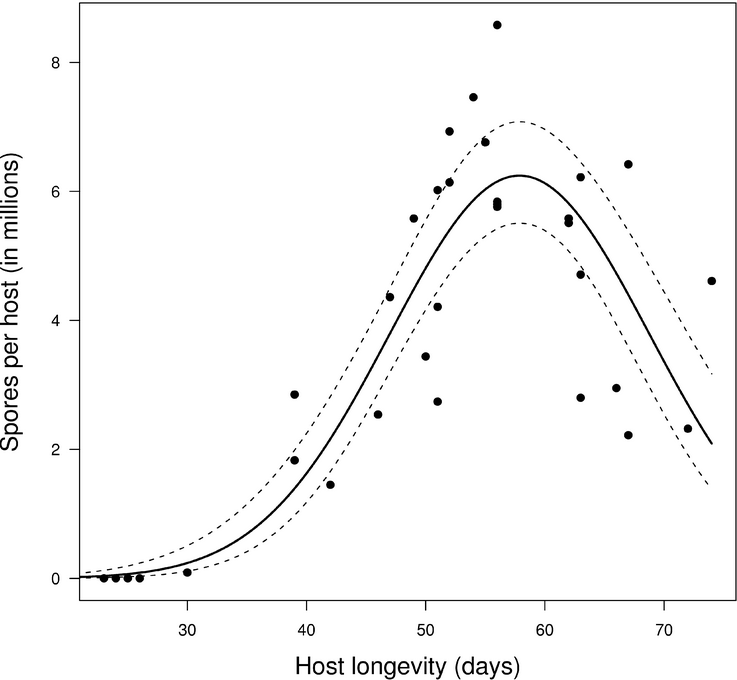

<sub>Jensen et al. 2006 *PLoS Biology*</sub>

### But we’ve only been thinking about parasite evolution

- It takes two to Red Queen, so we might expect hosts to evolve resistance
- And they do, but sometimes they don’t

### Why would a host not evolve resistance to a parasite?

- parasite does not impact host fitness *too much*
- resistance is costly
- they simply can’t (it’s not really a choice, right?)

### Resistance-tolerance tradeoffs

- A host can evolve to resist the effects of a parasite or to reduce parasite impacts
- These are often depicted as two separate responses to parasite pressure
- Resistance : infected hosts actively reduce parasite burden
- Tolerance : infected hosts try to limit damage to host fitness

### Resistance-tolerance tradeoffs

- This happens at individual level, but with implications to evolutionary trajectories
- Host fitness at one generation determines the allele frequency in the next
- So if tolerant hosts have highest fitness, it might result in evolution towards tolerating the parasite
- But at the population-level, this is a bad strategy (unless you’re a bat)

> Why is tolerance a bad population-level strategy?

### Let’s end on a community note

- Parasites can exert pressures on host communities
- Differential effects on host species can drive interesting dynamics

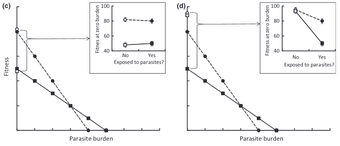

<sub>Rohr & Best 2010 *Functional Ecology*</sub>